# Lab 3 Quantum Measurements

Prerequisite

- [Ch.1.4 Single Qubit Gates](https://qiskit.org/textbook/ch-states/single-qubit-gates.html)
- [Ch.2.2 Multiple Qubits and Entangled States](https://qiskit.org/textbook/ch-gates/multiple-qubits-entangled-states.html)
- [Mitigating Noise on Real Quantum Computers](https://www.youtube.com/watch?v=yuDxHJOKsVA&list=PLOFEBzvs-Vvp2xg9-POLJhQwtVktlYGbY&index=8)

Other relevant materials

- [Feynman Lectures Ch. III - 12](https://www.feynmanlectures.caltech.edu/III_12.html)
- [Quantum Operation](https://qiskit.org/documentation/tutorials/circuits/3_summary_of_quantum_operations.html)
- [Interactive Bloch Sphere](https://nonhermitian.org/kaleido/stubs/kaleidoscope.interactive.bloch_sphere.html#kaleidoscope.interactive.bloch_sphere)
- [Ch.5.2 Measurement Error Mitigation](https://qiskit.org/textbook/ch-quantum-hardware/measurement-error-mitigation.html)

```python
from qiskit import *
import numpy as np

from qiskit import QuantumRegister, ClassicalRegister
from qiskit import transpile
from qiskit.quantum_info import random_statevector, Statevector

from numpy import linalg as la
#from qiskit.tools.monitor import job_monitor
from qiskit.visualization import plot_histogram
#import qiskit.tools.jupyter

from numpy import pi
from qiskit_aer import Aer
from qiskit_aer import AerSimulator
```

## Part 1: Measuring the state of a qubit

**Goal**

Determine the Bloch components of a qubit.

Fundamental to the operation of a quantum computer is the ability to compute the Bloch components of a qubit or qubits. These components correspond to the expectation values of the Pauli operators $X, Y, Z$, and are important quantities for applications such as quantum chemistry and optimization. Unfortunately, it is impossible to simultaneously compute these values, thus requiring many executions of the same circuit. In addition, measurements are restricted to the computational basis (Z-basis) so that each Pauli needs to be rotated to the standard basis to access the x and y components. Here we verify the methods by considering the case of a random vector on the Bloch sphere.

### 📓 1. Express the expectation values of the Pauli operators for an arbitrary qubit state $|q\rangle$ in the computational basis.

The case for the expectation value of Pauli Z gate is given as an example.

Using the diagonal representation, also known as spectral form or orthonormal decomposition, of Pauli $Z$ gate and the relations among the Pauli gates (see [here](https://qiskit.org/textbook/ch-states/single-qubit-gates.html)), expectation values of $ X, Y, Z $ gates can be written as

$$ \begin{align} \langle Z \rangle &=\langle q | Z | q\rangle =\langle q|0\rangle\langle 0|q\rangle - \langle q|1\rangle\langle 1|q\rangle =|\langle 0 |q\rangle|^2 - |\langle 1 | q\rangle|^2\\\\ \langle X \rangle &= \langle q | X | q\rangle =\langle q|1\rangle\langle 0|q\rangle - \langle q|0\rangle \langle 1|q\rangle\\\\ \langle Y \rangle &= \langle q | Y | q\rangle = i\langle q|1\rangle\langle 0|q\rangle - i\langle q|0\rangle\langle1|q\rangle \end{align} \\ $$ , respectively.

Therefore, the expectation values of the Paulis for a qubit state $|q\rangle$ can be obtained by making a measurement in the standard basis after rotating the standard basis frame to lie along the corresponding axis. The probabilities of obtaining the two possible outcomes 0 and 1 are used to evaluate the desired expectation value as the above equations show.

### 2. Measure the Bloch sphere coordinates of a qubit using the Aer simulator and plot the vector on the Bloch sphere.

#### 📓Step A. Create a qubit state using the circuit method, `initialize` with two random complex numbers as the parameter.

To learn how to use the function `initialize`, check [here](https://qiskit.org/documentation/tutorials/circuits/3_summary_of_quantum_operations.html#Arbitrary-initialization). (go to the `arbitrary initialization` section.)

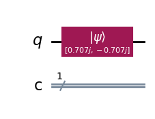

```python
qc = QuantumCircuit(1, 1)
qc.initialize([1.j/np.sqrt(2), -1.j/np.sqrt(2)], 0)
qc.draw()
```

#### 📓 Step B. Build the circuits to measure the expectation values of $X, Y, Z$ gate based on your answers to the question 1. Run the cell below to estimate the Bloch sphere coordinates of the qubit from step A using the Aer simulator.

The circuit for $Z$ gate measurement is given as an example.

```python
# z measurement of qubit 0
measure_z = QuantumCircuit(1,1)
measure_z.measure(0,0)

# x measurement of qubit 0
measure_x = QuantumCircuit(1,1)
measure_x.ry(-np.pi/2,0) # rotate around y-axis
measure_x.measure(0,0)


# y measurement of qubit 0
measure_y = QuantumCircuit(1,1)
measure_y.rx(np.pi/2,0)
measure_y.measure(0,0)



shots = 2**14 # number of samples used for statistics
sim = Aer.get_backend('aer_simulator')
bloch_vector_measure = []
for measure_circuit in [measure_x, measure_y, measure_z]:

    # run the circuit with the selected measurement and get the number of samples that output each bit value
    circ_trans = transpile(qc.compose(measure_circuit), sim)
    counts = sim.run(qc.compose(circ_trans), shots=shots).result().get_counts()

    # calculate the probabilities for each bit value
    probs = {}
    for output in ['0','1']:
        if output in counts:
            probs[output] = counts[output]/shots
        else:
            probs[output] = 0

    bloch_vector_measure.append( probs['0'] -  probs['1'] )

# normalizing the Bloch sphere vector
bloch_vector = bloch_vector_measure/la.norm(bloch_vector_measure)

print('The Bloch sphere coordinates are [{0:4.3f}, {1:4.3f}, {2:4.3f}]'
      .format(*bloch_vector))
```

```
The Bloch sphere coordinates are [-1.000, -0.007, -0.009]
```

#### Step C. Plot the vector on the Bloch sphere.

Note that the following cell for the interactive bloch_sphere would not run properly unless you work in [IQX](https://quantum-computing.ibm.com/login). You can either use `plot_bloch_vector` for the non-interactive version or install `kaleidoscope` by running

```
pip install kaleidoscope
```

```python
#from kaleidoscope.interactive import bloch_sphere
from qiskit.visualization import plot_bloch_vector
#bloch_sphere(bloch_vector, vectors_annotation=True)
```

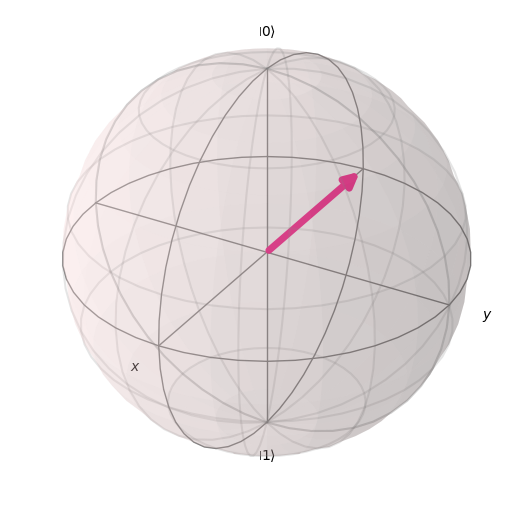

```python
from qiskit.visualization import plot_bloch_vector

plot_bloch_vector( bloch_vector )
```

## Part 2: Measuring Energy

**Goal**

Evaluate the energy levels of the hydrogen ground state using Aer simulator.

The energy of a quantum system can be estimated by measuring the expectation value of its Hamiltonian, which is a Hermitian operator, through the procedure we mastered in part 1.

The ground state of hydrogen is not defined as a single unique state but actually contains four different states due to the spins of the electron and proton. In part 2 of this lab, we evaluate the energy difference among these four states, which is from the `hyperfine splitting`, by computing the energy expectation value for the system of two spins with the Hamiltonian expressed in Pauli operators. For more information about `hyperfine structure`, see [here](https://www.feynmanlectures.caltech.edu/III_12.html)

Consider the system with two qubit interaction Hamiltonian $H = A(XX+YY+ZZ)$ where $A = 1.47e^{-6} eV$ and $X, Y, Z$ are Pauli gates. Then the energy expectation value of the system can be evaluated by combining the expectation value of each term in the Hamiltonian. In this case, $E = \langle H\rangle = A( \langle XX\rangle + \langle YY\rangle + \langle ZZ\rangle )$.

### 📓 1. Express the expectation value of each term in the Hamiltonian for an arbitrary two qubit state $|\psi \rangle$ in the computational basis.

The case for the term $\langle ZZ\rangle$ is given as an example.

$$ \begin{align} \langle ZZ\rangle &=\langle \psi | ZZ | \psi\rangle =\langle \psi|(|0\rangle\langle 0| - |1\rangle\langle 1|)\otimes(|0\rangle\langle 0| - |1\rangle\langle 1|) |\psi\rangle =|\langle 00|\psi\rangle|^2 - |\langle 01 | \psi\rangle|^2 - |\langle 10 | \psi\rangle|^2 + |\langle 11|\psi\rangle|^2\\\\ \langle XX\rangle &= \langle \psi | XX | \psi\rangle =\langle \psi|(0\rangle\langle 1| + |1\rangle\langle 0|) \otimes(|0\rangle\langle 1| + |1\rangle\langle 0|)|\psi\rangle =|\langle 01|\psi\rangle|^2 + |\langle 10|\psi\rangle|^2\\\\\ \langle YY\rangle &= \langle \psi | YY | \psi \rangle =\langle\psi|(-i|0\rangle\langle 1| + i|1\rangle\langle 0|) \otimes (-i|0\rangle\langle 1| + i|1\rangle\langle 0|)\psi\rangle = -|\langle 01|\psi\rangle|^2 - |\langle 10|\psi\rangle|^2 \end{align} $$

### 2. Measure the expected energy of the system using the Aer simulator when two qubits are entangled. Regard the bell basis, four different entangled states.

```python
# circuit for the state Tri1
Tri1 = QuantumCircuit(2, 2)
Tri1.x(1)
Tri1.h(0)
Tri1.cx(0, 1)

# circuit for the state Tri2
Tri2 = QuantumCircuit(2, 2)
Tri2.x(1)
Tri2.h(0)
Tri2.cx(0, 1)


# circuit for the state Tri3
Tri3 = QuantumCircuit(2, 2)
Tri3.x(1)
Tri3.h(0)
Tri3.cx(0, 1)


# circuit for the state Sing
Sing = QuantumCircuit(2, 2)
Sing.x(1)
Sing.h(0)
Sing.z(0)
Sing.z(1)
Sing.cx(0, 1)
```

```
<qiskit.circuit.instructionset.InstructionSet at 0x7fe692d97340>
```

#### 📓Step B. Create the circuits to measure the expectation value of each term in the Hamiltonian based on your answer to the question 1.

```python
# <ZZ>
measure_ZZ = QuantumCircuit(2)
measure_ZZ.measure_all()

# <XX>
measure_XX = QuantumCircuit(2)
measure_XX.h(0)
measure_XX.h(1)
measure_XX.measure_all()


# <YY>
measure_YY = QuantumCircuit(2)
measure_YY.h(0)
measure_YY.s(0)
measure_YY.h(1)
measure_YY.s(1)
measure_YY.measure_all()
```

#### Step C. Execute the circuits on Aer simulator by running the cell below and evaluate the energy expectation value for each state.

```python
shots = 2**14 # number of samples used for statistics

A = 1.47e-6 #unit of A is eV
E_sim = []
for state_init in [Tri1,Tri2,Tri3,Sing]:
    Energy_meas = []
    for measure_circuit in [measure_XX, measure_YY, measure_ZZ]:

        # run the circuit with the selected measurement and get the number of samples that output each bit value
        qc = state_init.compose(measure_circuit)
        qc_trans = transpile(qc, sim)
        counts = sim.run(qc_trans, shots=shots).result().get_counts()

        # calculate the probabilities for each computational basis
        probs = {}
        for output in ['00','01','10','11']:
            if output in counts:
                probs[output] = counts[output]/shots
            else:
                probs[output] = 0

        Energy_meas.append( probs['00'] - probs['01'] - probs['10'] + probs['11'] )

    E_sim.append(A * np.sum(np.array(Energy_meas)))
```

```python
# Run this cell to print out your results

print('Energy expectation value of the state Tri1 : {:.3e} eV'.format(E_sim[0]))
print('Energy expectation value of the state Tri2 : {:.3e} eV'.format(E_sim[1]))
print('Energy expectation value of the state Tri3 : {:.3e} eV'.format(E_sim[2]))
print('Energy expectation value of the state Sing : {:.3e} eV'.format(E_sim[3]))
```

```
Energy expectation value of the state Tri1 : 1.470e-06 eV
Energy expectation value of the state Tri2 : 1.470e-06 eV
Energy expectation value of the state Tri3 : 1.470e-06 eV
Energy expectation value of the state Sing : -4.410e-06 eV
```

#### Step D. Understanding the result.

If you found the energy expectation values successfully, you would have obtained exactly the same value, $A (= 1.47e^{-6} eV)$, for the triplet states, $|Tri1\rangle, |Tri2\rangle, |Tri3\rangle$ and one lower energy level, $-3A (= -4.41e^{-6} eV)$ for the singlet state $|Sing\rangle$.

What we have done here is measuring the energies of the four different spin states corresponding to the ground state of hydrogen and observed `hyperfine structure` in the energy levels caused by spin-spin coupling. This tiny energy difference between the singlet and triplet states is the reason for the famous 21-cm wavelength radiation used to map the structure of the galaxy.

In the cell below, we verify the wavelength of the emission from the transition between the triplet states and singlet state.

```python
# reduced plank constant in (eV) and the speed of light(cgs units)
hbar, c = 4.1357e-15, 3e10

# energy difference between the triplets and singlet
E_del = abs(E_sim[0] - E_sim[3])

# frequency associated with the energy difference
f = E_del/hbar

# convert frequency to wavelength in (cm)
wavelength = c/f

print('The wavelength of the radiation from the transition\
 in the hyperfine structure is : {:.1f} cm'.format(wavelength))
```

```
The wavelength of the radiation from the transition in the hyperfine structure is : 21.1 cm
```

## Part 3: Execute the circuits on Quantum Computer

**Goal**

Re-run the circuits on a IBM quantum system. Perform measurement error mitigations on the result to improve the accuracy in the energy estimation.

#### Step A. Run the following cells to load your account and select the backend

```python
from qiskit_ibm_provider import IBMProvider
provider = IBMProvider()
```

```python
backend = provider.get_backend('ibm_osaka')
```

#### Step B. Execute the circuits on the quantum system.

In Lab1 when we executed multiple circuits on a real quantum system, we submitted each circuit as a separate job which produces the multiple job ids. This time, we put all the circuits in a list and execute the list of the circuits as one job. In this way, all the circuit executions can happen at once, which would possibly decrease your wait time in the queue.

📓 Check the backend configuration information and error map through the widget to determine your `initial_layout`.

```python
# run this cell to get the backend information through the widget
backend
```

```
<IBMBackend('ibm_osaka')>
```

```python
# assign your choice for the initial layout to the list variable `initial_layout`.
initial_layout = 44, 45
```

Run the following cell to execute the circuits with the initial_layout on the backend.

```python
qc_all = [state_init.compose(measure_circuit) for state_init in [Tri1,Tri2,Tri3,Sing]
          for measure_circuit in [measure_XX, measure_YY, measure_ZZ] ]

shots = 8192
qc_all_trans = transpile(qc_all, backend, initial_layout=initial_layout, optimization_level=3)
job = backend.run(qc_all_trans, shots=shots)
print(job.job_id())
```

```
cr2s9ex989000089gs70
```

```python
# getting the results of your job
from qiskit_ibm_runtime import QiskitRuntimeService
service = QiskitRuntimeService(channel="ibm_quantum")

job = service.job('cr2s9ex989000089gs70')
results = job.result()
#results = provider.backend.retrieve_job(job.job_id('cqmefsqsvae000876dr0'))
```

```
qiskit_runtime_service.__init__:INFO:2024-04-04 15:06:06,832: Default instance: ibm-q/open/main
```

#### Step C. Estimate the ground state energy levels from the results of the previous step by executing the cells below.

```python
def Energy(results, shots):
    """Compute the energy levels of the hydrogen ground state.

    Parameters:
        results (obj): results, results from executing the circuits for measuring a Hamiltonian.
        shots (int): shots, number of shots used for the circuit execution.

    Returns:
        Energy (list): energy values of the four different hydrogen ground states
    """
    E = []
    A = 1.47e-6

    for ind_state in range(4):
        Energy_meas = []
        for ind_comp in range(3):
            counts = results.get_counts(ind_state*3+ind_comp)

            # calculate the probabilities for each computational basis
            probs = {}
            for output in ['00','01', '10', '11']:
                if output in counts:
                    probs[output] = counts[output]/shots
                else:
                    probs[output] = 0

            Energy_meas.append( probs['00'] - probs['01'] - probs['10'] + probs['11'] )

        E.append(A * np.sum(np.array(Energy_meas)))

    return E
```

```python
E = Energy(results, shots)

print('Energy expectation value of the state Tri1 : {:.3e} eV'.format(E[0]))
print('Energy expectation value of the state Tri2 : {:.3e} eV'.format(E[1]))
print('Energy expectation value of the state Tri3 : {:.3e} eV'.format(E[2]))
print('Energy expectation value of the state Sing : {:.3e} eV'.format(E[3]))
```

```
Energy expectation value of the state Tri1 : 5.805e-07 eV
Energy expectation value of the state Tri2 : 5.679e-07 eV
Energy expectation value of the state Tri3 : 5.789e-07 eV
Energy expectation value of the state Sing : -1.660e-06 eV
```

#### Step D. Measurement error mitigation.

The results you obtained from running the circuits on the quantum system are not exact due to the noise from the various sources such as enery relaxation, dephasing, crosstalk between qubits, etc. In this step, we will alleviate the effects of the noise through the measurement error mitigation. Before we start, watch this [video](https://www.youtube.com/watch?v=yuDxHJOKsVA&list=PLOFEBzvs-Vvp2xg9-POLJhQwtVktlYGbY&index=8).

```python
from qiskit_ibm_runtime import QiskitRuntimeService
from qiskit_ibm_runtime import EstimatorV2 as Estimator

service = QiskitRuntimeService()
backend = service.least_busy(operational=True, simulator=False)

# Setting options during primitive initialization
estimator = Estimator(backend, options={"resilience_level": 1})
```

```
qiskit_runtime_service.__init__:INFO:2024-04-04 15:07:54,126: Default instance: ibm-q/open/main
```

For further helpful information to complete this task, check [here](https://qiskit.org/textbook/ch-quantum-hardware/measurement-error-mitigation.html) .

```python
# assign your choice for the initial layout to the list variable `initial_layout`.
initial_layout = [2,3]
qc_all = [state_init.compose(measure_circuit) for state_init in [Tri1,Tri2,Tri3,Sing]
          for measure_circuit in [measure_XX, measure_YY, measure_ZZ] ]

shots = 8192
qc_all_trans = transpile(qc_all, backend, initial_layout=initial_layout, optimization_level=3)
job = backend.run(qc_all_trans, shots=shots)
print(job.job_id())

# getting the results of your job
results_new = job.result()
```

[output not shown]

```python
job = service.job('cr2s9ex989000089gs70')
results_new = job.result()
```

```python
E_new = Energy(results_new, shots)

print('Energy expection value of the state Tri1 : {:.3e} eV'.format(E_new[0]))
print('Energy expection value of the state Tri2 : {:.3e} eV'.format(E_new[1]))
print('Energy expection value of the state Tri3 : {:.3e} eV'.format(E_new[2]))
print('Energy expection value of the state Sing : {:.3e} eV'.format(E_new[3]))
```

[output not shown]

#### Step E. Interpret the result.

```python
# results for the energy estimation from the simulation,
# execution on a quantum system without error mitigation and
# with error mitigation in numpy array format
Energy_exact, Energy_exp_orig, Energy_exp_new = np.array(E_sim), np.array(E), np.array(E_new)
```

```python
# Calculate the relative errors of the energy values without error mitigation
# and assign to the numpy array variable `Err_rel_orig` of size 4
Err_rel_orig = np.abs(Energy_exact-Energy_exp_orig)
```

```python
# Calculate the relative errors of the energy values with error mitigation
# and assign to the numpy array variable `Err_rel_new` of size 4
Err_rel_new = np.abs(Energy_exact-Energy_exp_new)
```

```python
np.set_printoptions(precision=3)

print('The relative errors of the energy values for four bell basis\
 without measurement error mitigation : {}'.format(Err_rel_orig))
```

```
The relative errors of the energy values for four bell basis without measurement error mitigation : [8.895e-07 9.021e-07 8.911e-07 2.750e-06]
```

```python
np.set_printoptions(precision=3)

print('The relative errors of the energy values for four bell basis\
 with measurement error mitigation : {}'.format(Err_rel_new))
```

[output not shown]

📓 Compare the size of the errors before and after the measurment error mitigation and discuss about the effect of the readout error regarding the error map information of the backend that you selected.

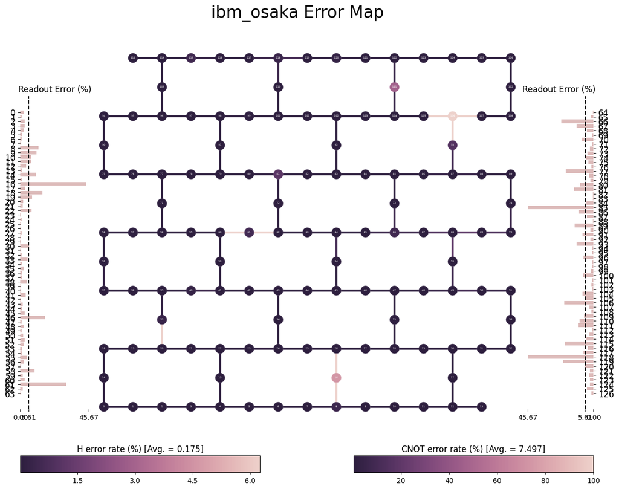

```python
from qiskit.visualization import plot_error_map
plot_error_map(backend)
```